# JilKothari

|  | **Exploratory Data Analysis** |
| --- | --- |

## Problem Statement

The zomato exploratory data analysis is for the foodies to find the best restaurants, value for money restaurants in their locality. It also helps to find their required cuisines in their locality.

## Data Definition

**res_id**: The code given to a restaurant (Categorical)

**name**: Name of the restaurant (Categorical)

**establishment**: Represents the type of establishment (Categorical)

**url**: The website of the restaurant (Categorical)

**address**: The address of the restaurant (Categorical)

**city**: City in which the restaurant located (Categorical)

**city_id**: The code given to a city (Categorical)

**locality**: Locality of the restaurant (Categorical)

**latitude**: Latitude of the restaurant (Categorical)

**longitude**: Longitude of the restaurant (Categorical)

**zipcode**: Zipcode of the city in which the restaurant located (Categorical)

**country_id**: Country code in which the restaurant located (Categorical)

**locality_verbose**: Locality along with the city in which the restaurant located (Categorical)

**cuisines**: The cuisines a restaurant serves (Categorical)

**timings**: The working hours of a restaurant (Categorical)

**average_cost_for_two**: The average amount expected for 2 people (Numerical)

**price_range**: The categories for average cost (Categories - 1,2,3,4) (Categorical)

**currency**: The currency in which a customer pays (Categorical)

**highlights**: The facilities of the restaurant (Categorical)

**aggregate_rating**: The overall rating a restaurant has got (Numerical)

**rating_text**: Categorized ratings (Categorical)

**votes**: Number of votes received by the restaurant from customers (Numerical)

**photo_count**: The number of photos of a restaurant (Numerical)

**opentable_support**: Restaurant reservation from Opentable (Categorical)

**delivery**: The restaurant deliver an order or not (Categorical)

**takeaway**: The restaurant allows a 'takeaway' of an order or not (Categorical)

1. **Import Libraries**
2. **Set Options**
3. **Read Data**
4. **Understand and Prepare the Data**
5. **Understand the variables**
6. **Check for Missing Values**
7. **Study Correlation**
8. **Detect Outliers**
9. **Create a new variable 'region'**
10. **Some more analysis**

## 1. Import Libraries

|  | **Import the required libraries and functions** |
| --- | --- |

```python
import pandas as pd
import numpy as np
```

## 2. Set Options

|  | Make necessary changes to : Set the working directory |
| --- | --- |

```python
!type pip
!type python
```

Inference- The directory was already set and hence no changes were needed to be I checked for the location of pip and python on the system.

## 3. Read Data

```python
data=pd.read_csv("ZomatoRestaurantsIndia.csv")
data
```

|  | res_id | name | establishment | url | address | city | city_id | locality | latitude | longitude | zipcode | country_id | locality_verbose | cuisines | timings | average_cost_for_two | price_range | currency | highlights | aggregate_rating | rating_text | votes | photo_count | opentable_support | delivery | takeaway |
| --- | --- | --- | --- | --- | --- | --- | --- | --- | --- | --- | --- | --- | --- | --- | --- | --- | --- | --- | --- | --- | --- | --- | --- | --- | --- | --- |
| 0 | 3400299 | Bikanervala | Quick Bites | https://www.zomato.com/agra/bikanervala-khanda... | Kalyani Point, Near Tulsi Cinema, Bypass Road,... | Agra | 34 | Khandari | 27.211450 | 78.002381 | NaN | 1 | Khandari, Agra | North Indian, South Indian, Mithai, Street Foo... | 8:30am – 10:30pm (Mon-Sun) | 700 | 2 | Rs. | Lunch, Takeaway Available, Credit Card, Dinner... | 4.4 | Very Good | 814 | 154 | 0.0 | -1 | -1 |
| 1 | 3400005 | Mama Chicken Mama Franky House | Quick Bites | https://www.zomato.com/agra/mama-chicken-mama-... | Main Market, Sadar Bazaar, Agra Cantt, Agra | Agra | 34 | Agra Cantt | 27.160569 | 78.011583 | 282001 | 1 | Agra Cantt, Agra | North Indian, Mughlai, Rolls, Chinese, Fast Fo... | 12:30PM to 12Midnight (Mon, Wed, Thu, Fri, Sat... | 600 | 2 | Rs. | Delivery, No Alcohol Available, Dinner, Takeaw... | 4.4 | Very Good | 1203 | 161 | 0.0 | -1 | -1 |
| 2 | 3401013 | Bhagat Halwai | Quick Bites | https://www.zomato.com/agra/bhagat-halwai-2-sh... | 62/1, Near Easy Day, West Shivaji Nagar, Goalp... | Agra | 34 | Shahganj | 27.182938 | 77.979684 | 282010 | 1 | Shahganj, Agra | Fast Food, Mithai | 9:30 AM to 11 PM | 300 | 1 | Rs. | No Alcohol Available, Dinner, Takeaway Availab... | 4.2 | Very Good | 801 | 107 | 0.0 | 1 | -1 |
| 3 | 3400290 | Bhagat Halwai | Quick Bites | https://www.zomato.com/agra/bhagat-halwai-civi... | Near Anjana Cinema, Nehru Nagar, Civil Lines, ... | Agra | 34 | Civil Lines | 27.205668 | 78.004799 | 282002 | 1 | Civil Lines, Agra | Desserts, Bakery, Fast Food, South Indian | 8am – 11pm (Mon-Sun) | 300 | 1 | Rs. | Takeaway Available, Credit Card, Lunch, Delive... | 4.3 | Very Good | 693 | 157 | 0.0 | 1 | -1 |
| 4 | 3401744 | The Salt Cafe Kitchen & Bar | Casual Dining | https://www.zomato.com/agra/the-salt-cafe-kitc... | 1C,3rd Floor, Fatehabad Road, Tajganj, Agra | Agra | 34 | Tajganj | 27.157709 | 78.052421 | NaN | 1 | Tajganj, Agra | North Indian, Continental, Italian | 11:30 AM to 11:30 PM | 1000 | 3 | Rs. | Lunch, Serves Alcohol, Cash, Credit Card, Dinn... | 4.9 | Excellent | 470 | 291 | 0.0 | 1 | -1 |
| ... | ... | ... | ... | ... | ... | ... | ... | ... | ... | ... | ... | ... | ... | ... | ... | ... | ... | ... | ... | ... | ... | ... | ... | ... | ... | ... |
| 211939 | 3202251 | Kali Mirch Cafe And Restaurant | Casual Dining | https://www.zomato.com/vadodara/kali-mirch-caf... | Manu Smriti Complex, Near Navrachna School, GI... | Vadodara | 32 | Fatehgunj | 22.336931 | 73.192356 | 390024 | 1 | Fatehgunj, Vadodara | North Indian | 11am – 3pm, 7pm – 11:30pm (Mon-Sun) | 600 | 2 | Rs. | Dinner, Cash, Lunch, Delivery, Indoor Seating,... | 4.1 | Very Good | 243 | 40 | 0.0 | -1 | -1 |
| 211940 | 3200996 | Raju Omlet | Quick Bites | https://www.zomato.com/vadodara/raju-omlet-kar... | Mahalaxmi Apartment, Opposite B O B, Karoli Ba... | Vadodara | 32 | Karelibaug | 22.322455 | 73.197203 | NaN | 1 | Karelibaug, Vadodara | Fast Food | 4pm – 11pm (Mon, Tue, Wed, Fri, Sat, Sun), 4pm... | 300 | 1 | Rs. | Dinner, Cash, Takeaway Available, Debit Card, ... | 4.1 | Very Good | 187 | 40 | 0.0 | 1 | -1 |
| 211941 | 18984164 | The Grand Thakar | Casual Dining | https://www.zomato.com/vadodara/the-grand-thak... | 3rd Floor, Shreem Shalini Mall, Opposite Conqu... | Vadodara | 32 | Alkapuri | 22.310563 | 73.171164 | NaN | 1 | Alkapuri, Vadodara | Gujarati, North Indian, Chinese | 11:30 AM to 3:30 PM, 7:30 PM to 11 PM | 700 | 2 | Rs. | Dinner, Cash, Debit Card, Lunch, Takeaway Avai... | 4.0 | Very Good | 111 | 38 | 0.0 | -1 | -1 |
| 211942 | 3201138 | Subway | Quick Bites | https://www.zomato.com/vadodara/subway-1-akota... | G-2, Vedant Platina, Near Cosmos, Akota, Vadodara | Vadodara | 32 | Akota | 22.270027 | 73.143068 | NaN | 1 | Akota, Vadodara | Fast Food, Sandwich, Salad | 8 AM to 1 AM | 500 | 2 | Rs. | Dinner, Delivery, Credit Card, Lunch, Cash, Ta... | 3.7 | Good | 128 | 34 | 0.0 | 1 | -1 |
| 211943 | 18879846 | Freshcos - The Health Cafe | Café | https://www.zomato.com/vadodara/freshcos-the-h... | Shop 7, Ground Floor, Opposite Natubhai Circle... | Vadodara | 32 | Vadiwadi | 22.309935 | 73.158768 | 390007 | 1 | Vadiwadi, Vadodara | Cafe, Healthy Food, Coffee | 7am – 11pm (Mon-Sun) | 600 | 2 | Rs. | Dinner, Cash, Takeaway Available, Debit Card, ... | 4.0 | Very Good | 93 | 53 | 0.0 | 1 | -1 |

211944 rows × 26 columns

Inference- Reading the data

## 4. Understand and Prepare the Data

A well-prepared data proves beneficial for analysis as it limits errors and inaccuracies that can occur during analysis. The processed data is more accessible to users.  
Data understanding is the process of getting familiar with the data, to identify data type, to discover first insights into the data, or to detect interesting subsets to form hypotheses about hidden information. Whereas, data preparation is the process of cleaning and transforming raw data before analysis. It is an important step before processing and often involves reformatting data, making corrections to data.  
Data preparation is often a lengthy process, but it is essential as a prerequisite to put data in context to get insights and eliminate bias resulting from poor data quality.

[figure not shown]

Analyze and prepare data:  
1. Check dimensions of the dataframe  
2. View the head of the data  
3. Note the redundant variables and drop them  
4. Check the data types. Refer to data definition to ensure your data types are correct. If data types are not as per business context, change the data types as per requirement  
5. Check for duplicates  
Note: It is an art to explore data and one will need more and more practice to gain expertise in this area

### ------------------------- *Provide the inference's from the output of every code executed.*----------------------------

**1. Check dimensions of the dataframe in terms of rows and columns**

```python
data.shape
```

```
(211944, 26)
```

Inference drawn:

```
* The no.of rows are 211944
* The no.of columns are 26
```

**2. View the head of the data**

```python
data.head(5)
# data.locality_verbose
```

|  | res_id | name | establishment | url | address | city | city_id | locality | latitude | longitude | zipcode | country_id | locality_verbose | cuisines | timings | average_cost_for_two | price_range | currency | highlights | aggregate_rating | rating_text | votes | photo_count | opentable_support | delivery | takeaway |
| --- | --- | --- | --- | --- | --- | --- | --- | --- | --- | --- | --- | --- | --- | --- | --- | --- | --- | --- | --- | --- | --- | --- | --- | --- | --- | --- |
| 0 | 3400299 | Bikanervala | Quick Bites | https://www.zomato.com/agra/bikanervala-khanda... | Kalyani Point, Near Tulsi Cinema, Bypass Road,... | Agra | 34 | Khandari | 27.211450 | 78.002381 | NaN | 1 | Khandari, Agra | North Indian, South Indian, Mithai, Street Foo... | 8:30am – 10:30pm (Mon-Sun) | 700 | 2 | Rs. | Lunch, Takeaway Available, Credit Card, Dinner... | 4.4 | Very Good | 814 | 154 | 0.0 | -1 | -1 |
| 1 | 3400005 | Mama Chicken Mama Franky House | Quick Bites | https://www.zomato.com/agra/mama-chicken-mama-... | Main Market, Sadar Bazaar, Agra Cantt, Agra | Agra | 34 | Agra Cantt | 27.160569 | 78.011583 | 282001 | 1 | Agra Cantt, Agra | North Indian, Mughlai, Rolls, Chinese, Fast Fo... | 12:30PM to 12Midnight (Mon, Wed, Thu, Fri, Sat... | 600 | 2 | Rs. | Delivery, No Alcohol Available, Dinner, Takeaw... | 4.4 | Very Good | 1203 | 161 | 0.0 | -1 | -1 |
| 2 | 3401013 | Bhagat Halwai | Quick Bites | https://www.zomato.com/agra/bhagat-halwai-2-sh... | 62/1, Near Easy Day, West Shivaji Nagar, Goalp... | Agra | 34 | Shahganj | 27.182938 | 77.979684 | 282010 | 1 | Shahganj, Agra | Fast Food, Mithai | 9:30 AM to 11 PM | 300 | 1 | Rs. | No Alcohol Available, Dinner, Takeaway Availab... | 4.2 | Very Good | 801 | 107 | 0.0 | 1 | -1 |
| 3 | 3400290 | Bhagat Halwai | Quick Bites | https://www.zomato.com/agra/bhagat-halwai-civi... | Near Anjana Cinema, Nehru Nagar, Civil Lines, ... | Agra | 34 | Civil Lines | 27.205668 | 78.004799 | 282002 | 1 | Civil Lines, Agra | Desserts, Bakery, Fast Food, South Indian | 8am – 11pm (Mon-Sun) | 300 | 1 | Rs. | Takeaway Available, Credit Card, Lunch, Delive... | 4.3 | Very Good | 693 | 157 | 0.0 | 1 | -1 |
| 4 | 3401744 | The Salt Cafe Kitchen & Bar | Casual Dining | https://www.zomato.com/agra/the-salt-cafe-kitc... | 1C,3rd Floor, Fatehabad Road, Tajganj, Agra | Agra | 34 | Tajganj | 27.157709 | 78.052421 | NaN | 1 | Tajganj, Agra | North Indian, Continental, Italian | 11:30 AM to 11:30 PM | 1000 | 3 | Rs. | Lunch, Serves Alcohol, Cash, Credit Card, Dinn... | 4.9 | Excellent | 470 | 291 | 0.0 | 1 | -1 |

Inference -

*There are 26 different columns in the dataset with data related to various aspects of sales related to Zomato

*The focus has is only on data related to the Indian subcontinent

**3. Note the redundant variables and drop them**

```python
data.columns

#country_id
#city
#country_id
#locality_verbose
#currency
#opentable_support

data=data.drop(['country_id','locality_verbose','currency','opentable_support'],axis=1)
```

The variables are

1) country_id - since focus is only for the country India and hence country_id is same everywhere

2) locality_verbose - address parameter is already given

3) currency - since it is only for India, the currency is constant

4) Opentable_support - all various are 0 hence can be dropped

```python
data.shape
```

```
(211944, 22)
```

Inference-

checking to undersand if the columns were droppped or not We can see that the columns reduced to 22 from 26

**4. Check the data types. Refer to data definition to ensure your data types are correct. If data types are not as per business context, change the data types as per requirement**

```python
data
data.dtypes
```

```
res_id                    int64
name                     object
establishment            object
url                      object
address                  object
city                     object
city_id                   int64
locality                 object
latitude                float64
longitude               float64
zipcode                  object
cuisines                 object
timings                  object
average_cost_for_two      int64
price_range               int64
highlights               object
aggregate_rating        float64
rating_text              object
votes                     int64
photo_count               int64
delivery                  int64
takeaway                  int64
dtype: object
```

Inference-

checking the datatype of the dataset

#### Change the incorrect data type

```python
#TO CATEGORICAL FORMAT

data=data.astype('category')

#TO NUMERICAL FORMAT

# average_cost_for_two
# aggregate_rating
# photo_count
# votes

data.average_cost_for_two=data.average_cost_for_two.astype('int64')
data.aggregate_rating=data.aggregate_rating.astype('float64')
data.photo_count=data.photo_count.astype('int64')
data.votes=data.votes.astype('int64')



data.dtypes
```

```
res_id                  category
name                    category
establishment           category
url                     category
address                 category
city                    category
city_id                 category
locality                category
latitude                category
longitude               category
zipcode                 category
cuisines                category
timings                 category
average_cost_for_two       int64
price_range             category
highlights              category
aggregate_rating         float64
rating_text             category
votes                      int64
photo_count                int64
delivery                category
takeaway                category
dtype: object
```

Inference-

- the datatypes were changed according to the business requirements into the two types- categorial/numerical

**5. Check for Duplicates**

```python
#this is done based on all columns in the data
data_duplicated=data[data.duplicated()]
data_duplicated
```

|  | res_id | name | establishment | url | address | city | city_id | locality | latitude | longitude | zipcode | cuisines | timings | average_cost_for_two | price_range | highlights | aggregate_rating | rating_text | votes | photo_count | delivery | takeaway |
| --- | --- | --- | --- | --- | --- | --- | --- | --- | --- | --- | --- | --- | --- | --- | --- | --- | --- | --- | --- | --- | --- | --- |
| 101 | 3400059 | Peshawri - ITC Mughal | Fine Dining | https://www.zomato.com/agra/peshawri-itc-mugha... | ITC Mughal, Fatehabad Road, Tajganj, Agra | Agra | 34 | ITC Mughal, Tajganj | 27.161150 | 78.043993 | NaN | North Indian, Mughlai | 12:30 PM to 2:45 PM, 7 PM to 11:45 PM | 6000 | 4 | Lunch, Cash, Credit Card, Dinner, Debit Card, ... | 4.4 | Very Good | 353 | 154 | -1 | -1 |
| 116 | 3400060 | Taj Bano - ITC Mughal | Fine Dining | https://www.zomato.com/agra/taj-bano-itc-mugha... | ITC Mughal, Fatehabad Road, Tajganj, Agra | Agra | 34 | ITC Mughal, Tajganj | 27.161132 | 78.044022 | NaN | Mughlai, North Indian | 6 AM to 10:30 AM, 12:30 PM to 2:30 PM, 7 PM to... | 2500 | 4 | Credit Card, Lunch, Cash, Debit Card, Dinner, ... | 4.3 | Very Good | 96 | 205 | -1 | -1 |
| 140 | 3400017 | Pinch Of Spice | Casual Dining | https://www.zomato.com/agra/pinch-of-spice-civ... | 23/453, Opposite Sanjay Cinema, Wazipura Road,... | Agra | 34 | Civil Lines | 27.201735 | 78.007625 | NaN | North Indian, Chinese, Mughlai | 12 Noon to 4 PM, 7 PM to 11:30 PM | 1600 | 4 | Lunch, Delivery, Credit Card, Dinner, Cash, Ta... | 4.6 | Excellent | 915 | 105 | 1 | -1 |
| 141 | 3400018 | Pinch Of Spice | Casual Dining | https://www.zomato.com/agra/pinch-of-spice-taj... | 1076/2, Fatehabad Road, Tajganj, Agra | Agra | 34 | Tajganj | 27.159649 | 78.043304 | 282010 | North Indian, Chinese, Continental | 12 Noon to 11:30 PM (Mon-Sun) | 1600 | 4 | Delivery, Dinner, Cash, Credit Card, Debit Car... | 4.6 | Excellent | 965 | 690 | 1 | -1 |
| 142 | 3400850 | Urban Deck | Casual Dining | https://www.zomato.com/agra/urban-deck-2-civil... | 5th Floor, The P L Palace Hotel, MG Road, Sanj... | Agra | 34 | Civil Lines | 27.199573 | 78.003699 | 282005 | Mexican, Italian, North Indian | 1PM to 12Midnight (Mon-Sun) | 1600 | 4 | Dinner, Cash, Debit Card, Takeaway Available, ... | 4.3 | Very Good | 672 | 192 | 1 | -1 |
| ... | ... | ... | ... | ... | ... | ... | ... | ... | ... | ... | ... | ... | ... | ... | ... | ... | ... | ... | ... | ... | ... | ... |
| 211937 | 18855810 | Biryani aur Baatein | Casual Dining | https://www.zomato.com/vadodara/biryani-aur-ba... | Shop 14, Atlantis K-10, A Wing, Genda Circle R... | Vadodara | 32 | Alkapuri | 22.317746 | 73.168043 | NaN | Biryani, Mughlai, Chinese | 11:30am – 3:30pm, 7:30pm – 1am (Mon-Sun) | 500 | 2 | Dinner, Cash, Takeaway Available, Debit Card, ... | 4.1 | Very Good | 154 | 96 | -1 | -1 |
| 211938 | 18662583 | Wok On Fire | Casual Dining | https://www.zomato.com/vadodara/wok-on-fire-fa... | Ground Floor 1, Rossette Building, Opposite Se... | Vadodara | 32 | Fatehgunj | 22.323357 | 73.187461 | NaN | Chinese, Asian | 11 AM to 11 PM | 1000 | 3 | Dinner, Cash, Debit Card, Lunch, Takeaway Avai... | 4.0 | Very Good | 301 | 126 | 1 | -1 |
| 211939 | 3202251 | Kali Mirch Cafe And Restaurant | Casual Dining | https://www.zomato.com/vadodara/kali-mirch-caf... | Manu Smriti Complex, Near Navrachna School, GI... | Vadodara | 32 | Fatehgunj | 22.336931 | 73.192356 | 390024 | North Indian | 11am – 3pm, 7pm – 11:30pm (Mon-Sun) | 600 | 2 | Dinner, Cash, Lunch, Delivery, Indoor Seating,... | 4.1 | Very Good | 243 | 40 | -1 | -1 |
| 211941 | 18984164 | The Grand Thakar | Casual Dining | https://www.zomato.com/vadodara/the-grand-thak... | 3rd Floor, Shreem Shalini Mall, Opposite Conqu... | Vadodara | 32 | Alkapuri | 22.310563 | 73.171164 | NaN | Gujarati, North Indian, Chinese | 11:30 AM to 3:30 PM, 7:30 PM to 11 PM | 700 | 2 | Dinner, Cash, Debit Card, Lunch, Takeaway Avai... | 4.0 | Very Good | 111 | 38 | -1 | -1 |
| 211943 | 18879846 | Freshcos - The Health Cafe | Café | https://www.zomato.com/vadodara/freshcos-the-h... | Shop 7, Ground Floor, Opposite Natubhai Circle... | Vadodara | 32 | Vadiwadi | 22.309935 | 73.158768 | 390007 | Cafe, Healthy Food, Coffee | 7am – 11pm (Mon-Sun) | 600 | 2 | Dinner, Cash, Takeaway Available, Debit Card, ... | 4.0 | Very Good | 93 | 53 | 1 | -1 |

151533 rows × 22 columns

Inference-

```
We can understand that there are about 151533 rows in the dataset having some/all values as repeated values
```

```python
#let us do for city column

data_city_dup=data[data['city'].duplicated()]
data_city_dup
```

|  | res_id | name | establishment | url | address | city | city_id | locality | latitude | longitude | zipcode | cuisines | timings | average_cost_for_two | price_range | highlights | aggregate_rating | rating_text | votes | photo_count | delivery | takeaway |
| --- | --- | --- | --- | --- | --- | --- | --- | --- | --- | --- | --- | --- | --- | --- | --- | --- | --- | --- | --- | --- | --- | --- |
| 1 | 3400005 | Mama Chicken Mama Franky House | Quick Bites | https://www.zomato.com/agra/mama-chicken-mama-... | Main Market, Sadar Bazaar, Agra Cantt, Agra | Agra | 34 | Agra Cantt | 27.160569 | 78.011583 | 282001 | North Indian, Mughlai, Rolls, Chinese, Fast Fo... | 12:30PM to 12Midnight (Mon, Wed, Thu, Fri, Sat... | 600 | 2 | Delivery, No Alcohol Available, Dinner, Takeaw... | 4.4 | Very Good | 1203 | 161 | -1 | -1 |
| 2 | 3401013 | Bhagat Halwai | Quick Bites | https://www.zomato.com/agra/bhagat-halwai-2-sh... | 62/1, Near Easy Day, West Shivaji Nagar, Goalp... | Agra | 34 | Shahganj | 27.182938 | 77.979684 | 282010 | Fast Food, Mithai | 9:30 AM to 11 PM | 300 | 1 | No Alcohol Available, Dinner, Takeaway Availab... | 4.2 | Very Good | 801 | 107 | 1 | -1 |
| 3 | 3400290 | Bhagat Halwai | Quick Bites | https://www.zomato.com/agra/bhagat-halwai-civi... | Near Anjana Cinema, Nehru Nagar, Civil Lines, ... | Agra | 34 | Civil Lines | 27.205668 | 78.004799 | 282002 | Desserts, Bakery, Fast Food, South Indian | 8am – 11pm (Mon-Sun) | 300 | 1 | Takeaway Available, Credit Card, Lunch, Delive... | 4.3 | Very Good | 693 | 157 | 1 | -1 |
| 4 | 3401744 | The Salt Cafe Kitchen & Bar | Casual Dining | https://www.zomato.com/agra/the-salt-cafe-kitc... | 1C,3rd Floor, Fatehabad Road, Tajganj, Agra | Agra | 34 | Tajganj | 27.157709 | 78.052421 | NaN | North Indian, Continental, Italian | 11:30 AM to 11:30 PM | 1000 | 3 | Lunch, Serves Alcohol, Cash, Credit Card, Dinn... | 4.9 | Excellent | 470 | 291 | 1 | -1 |
| 5 | 3400275 | Dominos Pizza | Quick Bites | https://www.zomato.com/agra/dominos-pizza-civi... | 114/23 G, Deep Shikha Complex, Sanjay Place, C... | Agra | 34 | Civil Lines | 27.201516 | 78.007556 | NaN | Pizza, Fast Food | 10:57 AM to 11 PM | 400 | 2 | Credit Card, Lunch, Delivery, Dinner, Debit Ca... | 4.0 | Very Good | 707 | 62 | -1 | -1 |
| ... | ... | ... | ... | ... | ... | ... | ... | ... | ... | ... | ... | ... | ... | ... | ... | ... | ... | ... | ... | ... | ... | ... |
| 211939 | 3202251 | Kali Mirch Cafe And Restaurant | Casual Dining | https://www.zomato.com/vadodara/kali-mirch-caf... | Manu Smriti Complex, Near Navrachna School, GI... | Vadodara | 32 | Fatehgunj | 22.336931 | 73.192356 | 390024 | North Indian | 11am – 3pm, 7pm – 11:30pm (Mon-Sun) | 600 | 2 | Dinner, Cash, Lunch, Delivery, Indoor Seating,... | 4.1 | Very Good | 243 | 40 | -1 | -1 |
| 211940 | 3200996 | Raju Omlet | Quick Bites | https://www.zomato.com/vadodara/raju-omlet-kar... | Mahalaxmi Apartment, Opposite B O B, Karoli Ba... | Vadodara | 32 | Karelibaug | 22.322455 | 73.197203 | NaN | Fast Food | 4pm – 11pm (Mon, Tue, Wed, Fri, Sat, Sun), 4pm... | 300 | 1 | Dinner, Cash, Takeaway Available, Debit Card, ... | 4.1 | Very Good | 187 | 40 | 1 | -1 |
| 211941 | 18984164 | The Grand Thakar | Casual Dining | https://www.zomato.com/vadodara/the-grand-thak... | 3rd Floor, Shreem Shalini Mall, Opposite Conqu... | Vadodara | 32 | Alkapuri | 22.310563 | 73.171164 | NaN | Gujarati, North Indian, Chinese | 11:30 AM to 3:30 PM, 7:30 PM to 11 PM | 700 | 2 | Dinner, Cash, Debit Card, Lunch, Takeaway Avai... | 4.0 | Very Good | 111 | 38 | -1 | -1 |
| 211942 | 3201138 | Subway | Quick Bites | https://www.zomato.com/vadodara/subway-1-akota... | G-2, Vedant Platina, Near Cosmos, Akota, Vadodara | Vadodara | 32 | Akota | 22.270027 | 73.143068 | NaN | Fast Food, Sandwich, Salad | 8 AM to 1 AM | 500 | 2 | Dinner, Delivery, Credit Card, Lunch, Cash, Ta... | 3.7 | Good | 128 | 34 | 1 | -1 |
| 211943 | 18879846 | Freshcos - The Health Cafe | Café | https://www.zomato.com/vadodara/freshcos-the-h... | Shop 7, Ground Floor, Opposite Natubhai Circle... | Vadodara | 32 | Vadiwadi | 22.309935 | 73.158768 | 390007 | Cafe, Healthy Food, Coffee | 7am – 11pm (Mon-Sun) | 600 | 2 | Dinner, Cash, Takeaway Available, Debit Card, ... | 4.0 | Very Good | 93 | 53 | 1 | -1 |

211846 rows × 22 columns

Inference-

We can observe that since there are only 98 unique cities in the dataset, and there are 211944 values , there rest i.e (211944-98) are duplicated values

## 5. Understand the variables

**1. Variable 'name'**

```python
data.name
```

```
0                            Bikanervala
1         Mama Chicken Mama Franky House
2                          Bhagat Halwai
3                          Bhagat Halwai
4            The Salt Cafe Kitchen & Bar
                       ...
211939    Kali Mirch Cafe And Restaurant
211940                        Raju Omlet
211941                  The Grand Thakar
211942                            Subway
211943        Freshcos - The Health Cafe
Name: name, Length: 211944, dtype: category
Categories (40965, object): [# Wednesday, #1, Culinary Avenue - The Red Maple, #788 Avenue, #BC,
                             ..., ट 4 Tasty, द Vege टेबल, स्पेस Bar, ह-tea The Tea Hut]
```

Inference-

```
This column states the names of all the restaurants registered with zomato in india
```

**2. Variable 'establishment'**

```python
data.establishment
```

```
0           Quick Bites
1           Quick Bites
2           Quick Bites
3           Quick Bites
4         Casual Dining
              ...
211939    Casual Dining
211940      Quick Bites
211941    Casual Dining
211942      Quick Bites
211943             Café
Name: establishment, Length: 211944, dtype: category
Categories (26, object): [Bakery, Bar, Beverage Shop, Bhojanalya, ..., Pub, Quick Bites, Shack,
                          Sweet Shop]
```

Inference-

```
This shows what type of restaurant is it namely quick biting, casual dining, cafe and so on
```

**3. Variable 'city'**

```python
data.city
```

```
0             Agra
1             Agra
2             Agra
3             Agra
4             Agra
            ...
211939    Vadodara
211940    Vadodara
211941    Vadodara
211942    Vadodara
211943    Vadodara
Name: city, Length: 211944, dtype: category
Categories (98, object): [Agra, Ahmedabad, Ajmer, Alappuzha, ..., Vellore, Vijayawada, Vizag,
                          Zirakpur]
```

Inference-

```
Understanding the names of the cities in the dataset
```

**Let us find the count of restaurants in each city**

```python
data.city.value_counts()
```

```
Chennai          11630
Mumbai            6497
Bangalore         4971
Pune              4217
Lucknow           4121
                 ...
Ghaziabad          132
Faridabad          124
Howrah              66
Greater Noida       33
Nayagaon            17
Name: city, Length: 98, dtype: int64
```

Inference-

```
  Counting the no.of restaurants in a specific city in india with the help of value_counts() function of pandas
```

**4. Variable 'locality'**

```python
data.locality
```

```
0            Khandari
1          Agra Cantt
2            Shahganj
3         Civil Lines
4             Tajganj
             ...
211939      Fatehgunj
211940     Karelibaug
211941       Alkapuri
211942          Akota
211943       Vadiwadi
Name: locality, Length: 211944, dtype: category
Categories (3731, object): [32nd Avenue, NH8, Gurgaon, 800 Jubilee, Jubilee Hills,
                            Hotel Somdeep Palace, Vijay Nagar, ILD Trade Centre Mall, Sohna Road, ...,
                            Zone by The Park, Pallikaranai, Zone by the Park, Bani Park, Zoo Tiniali,
                            lebua Lucknow]
```

Inference-

```
    Understanding the locality where the restaurant is situated
```

**4. Variable 'latitude'**

From the variable 'latitude', we know the latitudinal location of the restaurant

The Latitudinal extent of India 8º4‛N to 37º6‛ N.

We must check whether we have any points beyond this extent.

- We need to replace all these values with NaN's.
- check if the values are replace by NaN's
- We see all the values are replaced by NaN's

```python
data.latitude
```

```
0         27.211450
1         27.160569
2         27.182938
3         27.205668
4         27.157709
            ...
211939    22.336931
211940    22.322455
211941    22.310563
211942    22.270027
211943    22.309935
Name: latitude, Length: 211944, dtype: category
Categories (53356, float64): [0.000000, 0.058594, 1.027194, 6.713063, ..., 34.200778, 34.214702,
                              75.791315, 10000.000000]
```

Inference-

```
    reading the latitudes
```

```python
data.latitude.isna().sum()
```

```
0
```

```python
data.latitude=data.latitude.astype('Float64')
data.loc[(data.latitude<8.4)| (data.latitude >37.6),['latitude']]=None
```

Inference-

```
    This shows that if a latitude is not within the given paramaters we can say that it does not lie in the indian subcontinent and hence we can replace those values by null values since they are not benificial for us
```

```python
data.latitude.isna().sum()
```

```
1339
```

**5. Variable 'longitude'**

From the variable 'longitude', we know the longitudinal location of the restaurant

The Longitudinal extent of India is from 68°7'E to 97°25'E

We must check whether we have any points beyond this extent.

- We need to replace all these values with NaN's.
- Check if the values are replace by NaN's
- From variable 'latitude' and 'longitude', plot the location of restaurants.

```python
data.longitude
```

```
0         78.002381
1         78.011583
2         77.979684
3         78.004799
4         78.052421
            ...
211939    73.192356
211940    73.197203
211941    73.171164
211942    73.143068
211943    73.158768
Name: longitude, Length: 211944, dtype: category
Categories (53318, float64): [0.000000, 44.045241, 69.014446, 69.175883, ..., 91.828076, 91.828133,
                              91.829984, 91.832769]
```

Inference-

```
    reading the longtitude
```

```python
data.longitude.isna().sum()
```

```
0
```

```python
data.longitude=data.longitude.astype('Float64')
data.loc[(data.longitude<68.7)| (data.longitude >97.25),['longitude']]=None
```

Inference-

```
    This shows that if a longitude is not within the given paramaters we can say that it does not lie in the indian subcontinent and hence we can replace those values by null values since they are not benificial for us
```

```python
data.longitude.isna().sum()
```

```
1329
```

```python
!pip install git+git://github.com/geopandas/geopandas.git
```

```
  Cloning git://github.com/geopandas/geopandas.git to /tmp/pip-req-build-l08a48qh
  Running command git clone -q git://github.com/geopandas/geopandas.git /tmp/pip-req-build-l08a48qh
     |████████████████████████████████| 14.7MB 303kB/s
     |████████████████████████████████| 10.4MB 42.6MB/s
```

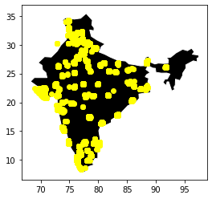

```python
import matplotlib.pyplot as plt
import geopandas

gdf = geopandas.GeoDataFrame(
    data, geometry=geopandas.points_from_xy(data.longitude, data.latitude))
gdf

world = geopandas.read_file(geopandas.datasets.get_path('naturalearth_lowres'))
ax = world[world.name == 'India'].plot(
    color='black', edgecolor='white')
gdf.plot(ax=ax, color='yellow',figsize=(50,50))
```

Inference-

```
    *Plotting the various coordinates of the restaurants across India
    *The yellow dots indicate the various locations where the restaurants are situated
```

**6. Variable 'cuisines'**

```python
data.cuisines
```

```
0         North Indian, South Indian, Mithai, Street Foo...
1         North Indian, Mughlai, Rolls, Chinese, Fast Fo...
2                                         Fast Food, Mithai
3                 Desserts, Bakery, Fast Food, South Indian
4                        North Indian, Continental, Italian
                                ...
211939                                         North Indian
211940                                            Fast Food
211941                      Gujarati, North Indian, Chinese
211942                           Fast Food, Sandwich, Salad
211943                           Cafe, Healthy Food, Coffee
Name: cuisines, Length: 211944, dtype: category
Categories (9382, object): [Afghan, Afghan, American,
                            Afghan, Arabian, BBQ, Beverages, Biryani, Maha..., Afghan, Arabian, BBQ, Beverages, Burger, ...,
                            Wraps, Sandwich, Pizza, Bakery, Wraps, Sandwich, Rolls, Fast Food, Burger,
                            Wraps, Sandwich, Rolls, Pizza, Burger, Wraps, Sandwich, Salad, Pizza, Burger, Beverages]
```

Inference-

```
    *Cuisines are the various types of foods offered by the various restaurants
```

- To find the unique cusines we write a small user defined function.

```python
def cuisines(x):
    save_cuisines=(list(map(str,(x))))
    result_cuisines=set()
    for i in save_cuisines:
        inter=(i.split(", "))
        for j in inter:
            result_cuisines.add(j)


    return (result_cuisines)
```

Inference-

```
    Function for finding out unique cuisines
```

- find out the frequency of each cuisine

```python
result_cuisines=cuisines(data.cuisines)

print(result_cuisines)
```

```
{'Falafel', 'Momos', 'Tea', 'Salad', 'Mangalorean', 'Mexican', 'BBQ', 'Malwani', 'Mithai', 'Konkan', 'Coffee', 'British', 'Charcoal Chicken', 'Healthy Food', 'Russian', 'Mishti', 'Egyptian', 'nan', 'Brazilian', 'Mughlai', 'South American', 'Panini', 'Andhra', 'Sushi', 'Gujarati', 'South Indian', 'Si…
```

Inference-

```
    these are the various unique cuisines offered by the restaurants pan India
```

```python
store_cuisine_inter=[]

df_cuisine=pd.DataFrame(result_cuisines,columns=['Cuisines'])
for i in result_cuisines:
    store_cuisine_inter.append(data['cuisines'].str.count(i).sum())


df_cuisine['frequency']=store_cuisine_inter
df_cuisine
```

|  | Cuisines | frequency |
| --- | --- | --- |
| 0 | Falafel | 7.0 |
| 1 | Momos | 4189.0 |
| 2 | Tea | 1220.0 |
| 3 | Salad | 3298.0 |
| 4 | Mangalorean | 396.0 |
| ... | ... | ... |
| 129 | Irish | 12.0 |
| 130 | Oriental | 14.0 |
| 131 | Belgian | 43.0 |
| 132 | Fried Chicken | 31.0 |
| 133 | Cake | 3.0 |

134 rows × 2 columns

Inference-

[output not shown]

**8. Variable 'average_cost_for_two'**

```python
data.average_cost_for_two
```

```
0          700
1          600
2          300
3          300
4         1000
          ...
211939     600
211940     300
211941     700
211942     500
211943     600
Name: average_cost_for_two, Length: 211944, dtype: int64
```

Inference-

```
    Getting the idea how much would it cost for two people to have food at that restaurant
```

**9. Variable 'price_range'**

```python
data.price_range
```

```
0         2
1         2
2         1
3         1
4         3
         ..
211939    2
211940    1
211941    2
211942    2
211943    2
Name: price_range, Length: 211944, dtype: category
Categories (4, int64): [1, 2, 3, 4]
```

Inference-

```
    understanding the price range and trying to make an better understanding of how costly is the restaurant
```

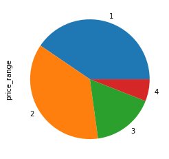

```python
data.price_range.value_counts().plot.pie()
```

Inference-

```
    understanding the price range of the restaurants and analysing the no.of restaurants in a particular price range
```

**10. Variable 'highlights'**

```python
data.highlights
```

```
0         Lunch, Takeaway Available, Credit Card, Dinner...
1         Delivery, No Alcohol Available, Dinner, Takeaw...
2         No Alcohol Available, Dinner, Takeaway Availab...
3         Takeaway Available, Credit Card, Lunch, Delive...
4         Lunch, Serves Alcohol, Cash, Credit Card, Dinn...
                                ...
211939    Dinner, Cash, Lunch, Delivery, Indoor Seating,...
211940    Dinner, Cash, Takeaway Available, Debit Card, ...
211941    Dinner, Cash, Debit Card, Lunch, Takeaway Avai...
211942    Dinner, Delivery, Credit Card, Lunch, Cash, Ta...
211943    Dinner, Cash, Takeaway Available, Debit Card, ...
Name: highlights, Length: 211944, dtype: category
Categories (31454, object): [Air Conditioned, Air Conditioned, Desserts and Bakes, Indoor Se...,
                             Air Conditioned, Desserts and Bakes, Pure Veg, Air Conditioned, Pure Veg, Desserts and Bakes, ...,
                             Takeaway Available, Standing Tables, Cash, Dig..., Takeaway Available, Standing Tables, Cash, Dinner,
                             Takeaway Available, Standing Tables, Credit Ca..., Wifi, Desserts and Bakes, Outdoor Seating]
```

Inference-

```
    Understanding the various important aspects of the restaurant
```

- write a small function to know the number of times a facility has appeared in the 'Highlights'.

```python
def highlights(x):
    save_highlights=(list(map(str,(x))))
    result_highlights=set()
    for i in save_highlights:
        inter=(i.split(", "))
        for j in inter:
            result_highlights.add(j)


    return (result_highlights)
```

Inference-

[output not shown]

```python
ans_highlights=highlights(data.highlights)
store_inter=[]

df_highlights=pd.DataFrame(ans_highlights,columns=['Facility'])
for i in ans_highlights:
    store_inter.append(data['highlights'].str.count(i).sum())


df_highlights
```

|  | Facility |
| --- | --- |
| 0 | Table Reservation Not Required |
| 1 | Gluten Free Options |
| 2 | Craft Beer |
| 3 | Delivery |
| 4 | Table booking recommended |
| ... | ... |
| 99 | Card Upon Delivery |
| 100 | 4/5 Star |
| 101 | Gin Bar |
| 102 | Wine |
| 103 | Gastro Pub |

104 rows × 1 columns

```python
# print(store_inter)
df_highlights['frequency']=store_inter
df_highlights
```

|  | Facility | frequency |
| --- | --- | --- |
| 0 | Table Reservation Not Required | 15763.0 |
| 1 | Gluten Free Options | 735.0 |
| 2 | Craft Beer | 945.0 |
| 3 | Delivery | 97589.0 |
| 4 | Table booking recommended | 31071.0 |
| ... | ... | ... |
| 99 | Card Upon Delivery | 343.0 |
| 100 | 4/5 Star | 4635.0 |
| 101 | Gin Bar | 127.0 |
| 102 | Wine | 4100.0 |
| 103 | Gastro Pub | 469.0 |

104 rows × 2 columns

Inference-

```
    Finding the frequency of the various facilities offered by the restaurants over India
```

- Now we find out which facility occurs most number of in the data.

```python
save_df=df_highlights.sort_values(by=['frequency'],ascending=False).head(1)
save_df['Facility'].head(1)
```

```
57    Cash
Name: Facility, dtype: object
```

Inference-

```
    we understand that cash is the most frequent facility offered by the restaurants
```

**11. Variable 'aggregate_rating'**

```python
data.aggregate_rating
```

```
0         4.4
1         4.4
2         4.2
3         4.3
4         4.9
         ...
211939    4.1
211940    4.1
211941    4.0
211942    3.7
211943    4.0
Name: aggregate_rating, Length: 211944, dtype: float64
```

Inference-

[output not shown]

**12. Variable 'rating_text'**

```python
data.rating_text
```

```
0         Very Good
1         Very Good
2         Very Good
3         Very Good
4         Excellent
            ...
211939    Very Good
211940    Very Good
211941    Very Good
211942         Good
211943    Very Good
Name: rating_text, Length: 211944, dtype: category
Categories (39, object): [Average, Baik, Bardzo dobrze, Biasa, ..., Wybitnie, Çok iyi, İyi, Średnio]
```

Inference-

```
    understanding the rating of the restaurant in descriptive format
```

Creating a New feature for better understanding of ratings

```python
data.rating_text.unique()

data.loc[((data.aggregate_rating>=0) & (data.aggregate_rating<=1)),'rating_text_new']='poor'
data.loc[((data.aggregate_rating>=1) & (data.aggregate_rating<=2)),'rating_text_new']='average'
data.loc[((data.aggregate_rating>=2) & (data.aggregate_rating<=3)),'rating_text_new']='good'
data.loc[((data.aggregate_rating>=3) & (data.aggregate_rating<=4)),'rating_text_new']='very good'
data.loc[((data.aggregate_rating>=4) & (data.aggregate_rating<=5)),'rating_text_new']='excellent'
data['rating_text_new'].unique()
```

```
array(['excellent', 'very good', 'poor', 'good', 'average'], dtype=object)
```

Inference-

```
    Creating a new column with range defined from 0 to 5 in five parts and assining each range an ordinal value
```

**13. Variable 'votes'**

```python
data.votes
```

```
0          814
1         1203
2          801
3          693
4          470
          ...
211939     243
211940     187
211941     111
211942     128
211943      93
Name: votes, Length: 211944, dtype: int64
```

Inference-

```
This shows the votes that are given to the restaurants by the customers visiting it
```

**14. Variable 'photo_count'**

```python
data.photo_count
```

```
0         154
1         161
2         107
3         157
4         291
         ...
211939     40
211940     40
211941     38
211942     34
211943     53
Name: photo_count, Length: 211944, dtype: int64
```

Inference-

```
This shows what are the no.of photos that uploaded by the customers visting the restaurant
```

**15. Variable 'delivery'**

```python
data.delivery
```

```
0        -1
1        -1
2         1
3         1
4         1
         ..
211939   -1
211940    1
211941   -1
211942    1
211943    1
Name: delivery, Length: 211944, dtype: category
Categories (3, int64): [-1, 0, 1]
```

Inference-

[output not shown]

## 6. Check for missing values

```python
data.isna().sum()
```

```
res_id                       0
name                         0
establishment             4827
url                          0
address                    134
city                         0
city_id                      0
locality                     0
latitude                  1339
longitude                 1329
zipcode                 163187
cuisines                  1391
timings                   3874
average_cost_for_two         0
price_range                  0
highlights                2069
aggregate_rating             0
rating_text                  0
votes                        0
photo_count                  0
delivery                     0
takeaway                     0
geometry                     0
rating_text_new              0
dtype: int64
```

Inference-

[output not shown]

**6. Study summary statistics**

Let us check the summary statistics for numerical variables.

```python
data.describe()
```

|  | latitude | longitude | average_cost_for_two | aggregate_rating | votes | photo_count |
| --- | --- | --- | --- | --- | --- | --- |
| count | 210605.000000 | 210615.000000 | 211944.000000 | 211944.000000 | 211944.000000 | 211944.000000 |
| mean | 21.586832 | 78.104827 | 595.812229 | 3.395937 | 378.002571 | 256.971224 |
| std | 6.823595 | 4.286852 | 606.239363 | 1.283642 | 925.333106 | 867.668940 |
| min | 8.400144 | 69.014446 | 0.000000 | 0.000000 | 0.000000 | 0.000000 |
| 25% | 15.545368 | 74.892431 | 250.000000 | 3.300000 | 16.000000 | 3.000000 |
| 50% | 22.541707 | 77.434536 | 400.000000 | 3.800000 | 100.000000 | 18.000000 |
| 75% | 26.847055 | 80.221799 | 700.000000 | 4.100000 | 362.000000 | 128.000000 |
| max | 34.214702 | 91.832769 | 30000.000000 | 4.900000 | 42539.000000 | 17702.000000 |

Inference-

```
This shows what are the the most extreme values in the data set (the maximum and minimum values), the lower and upper quartiles, and the median
```

## 7. Study correlation

```python
import seaborn as sns
corr=data.corr()
sns.heatmap(corr,annot=True)
```

[output not shown]